# Demonstration of Experiments (paper IJGI)

Ming Li

Tuesday, August 19, 2014

First, we load the libraries, functions, and data into the workspace.Following is a summary of the dataset.

```
##       gid             user_id            gender
##  Min.   :      1   Min.   :      32   female:235071
##  1st Qu.: 254982   1st Qu.: 1514021   male  :285587
##  Median : 506430   Median : 6820154   NA's  :  7707
##  Mean   : 505864   Mean   :15433981
##  3rd Qu.: 756951   3rd Qu.:21518413
##  Max.   :1135513   Max.   :88116325
##
##                      venue_id          lat.x          lon.x
##  43a52546f964a520532c1fe3: 11454   Min.   :40.5   Min.   :-74.2
##  4ace6c89f964a52078d020e3:  7211   1st Qu.:40.7   1st Qu.:-74.0
##  42911d00f964a520f5231fe3:  3224   Median :40.7   Median :-74.0
##  4ae6363ef964a520aba521e3:  2886   Mean   :40.7   Mean   :-74.0
##  49b7ed6df964a52030531fe3:  2518   3rd Qu.:40.8   3rd Qu.:-74.0
##  42829c80f964a5206a221fe3:  1999   Max.   :40.9   Max.   :-73.7
##  (Other)                 :499073
##   timestamps.x                             cate_l1
##  Min.   :1.39e+09   Food                       :155557
##  1st Qu.:1.39e+09   Shop & Service             : 83006
##  Median :1.40e+09   Nightlife Spot             : 63810
##  Mean   :1.40e+09   Travel & Transport         : 56886
##  3rd Qu.:1.40e+09   Arts & Entertainment       : 55195
##  Max.   :1.40e+09   Professional & Other Places: 52477
##                     (Other)                    : 61434
##                  cate_l2          datetime
##  Gym / Fitness Center: 29733   Min.   :2014-02-01 00:00:04
##  Bar                 : 22697   1st Qu.:2014-03-07 18:23:26
##  Airport             : 22678   Median :2014-04-09 17:42:47
##  Office              : 22552   Mean   :2014-04-09 01:49:43
##  Coffee Shop         : 16887   3rd Qu.:2014-05-11 14:30:32
##  American Restaurant : 14160   Max.   :2014-06-13 23:58:32
##  (Other)             :399658   NA's   :69
##               conds           winddird        windspd        temperatur
##  Clear           :255476   Min.   :  0.0   Min.   : 0      Min.   :-12.2
##  Overcast        :131709   1st Qu.:  0.0   1st Qu.: 6      1st Qu.:  3.3
##  Mostly Cloudy   : 42028   Median :  0.0   Median : 9      Median : 11.7
##  Partly Cloudy   : 28428   Mean   : 96.5   Mean   :10      Mean   : 10.7
##  Scattered Clouds: 23741   3rd Qu.:220.0   3rd Qu.:13      3rd Qu.: 17.8
##  Light Rain      : 18414   Max.   :360.0   Max.   :35      Max.   : 30.0
##  (Other)         : 28569                   NA's   :33147   NA's   :188
```

[output cut: 9 more lines]

```
##  Mode :logical   19     : 52321   Length:528365      Length:528365
##  FALSE:528365    18     : 47742   Class :character   Class :character
##  NA's :0         20     : 41059   Mode  :character   Mode  :character
##                  13     : 35048
##                  17     : 34523
##                  14     : 32393
##                  (Other):285279
##     isweekend
##  Saturday: 96134
##  Sunday  : 77757
##  Workday :354474
##
##
##
##
```

### 1. Temporal analysis

#### Frequency domain

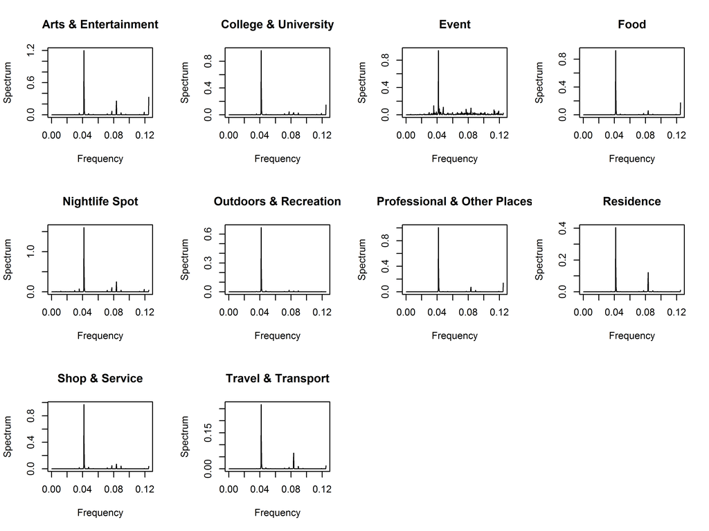

```r
L_category = split(checkin.global, checkin.global$cate_l1)

DF_date_hour_category = data.frame()
temp = lapply(L_category, function(i){
    df = stats_by_date_hour(i, category = i[1,"cate_l1"])
    DF_date_hour_category <<- rbind(DF_date_hour_category,df)
})

L_date_hour_category=split(DF_date_hour_category,DF_date_hour_category$cate_l1)
## plot
par(mfrow=c(3,4))
temp = lapply(seq_along(L_date_hour_category), function(i){
    fre = spec.pgram(L_date_hour_category[[i]]$prop, plot=FALSE)
    plot(fre[["freq"]][1:400], fre[["spec"]][1:400],
         type="l", main= names(L_date_hour_category[i]),
         xlab="Frequency", ylab="Spectrum")
    })
rm(temp)
```

#### Probability distribution

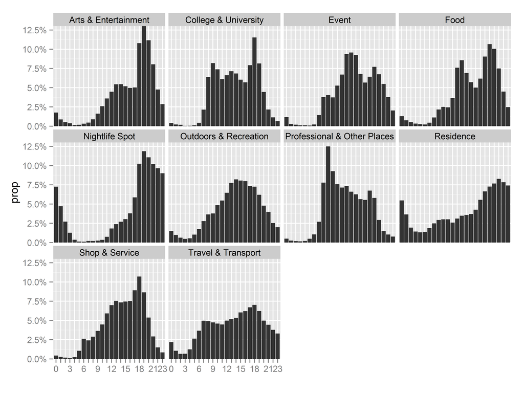

```r
DF_hour_category = data.frame()
temp = lapply(L_category, function(i){
    df = stats_checkin_by_hour(i, category = i[1,"cate_l1"])
    DF_hour_category <<- rbind(DF_hour_category,df)
})
rm(temp)
## plot
ggplot(DF_hour_category, aes(x=hour,y=prop)) +
    geom_bar(stat="identity") +
    xlab("") +
    facet_wrap(~cate_l1, ncol=4, nrow=3) +
    coord_cartesian(ylim = c(0,0.13)) +
    scale_y_continuous(labels  = percent) +
    scale_x_discrete(breaks=levels(DF_hour_category$hour),
                     labels=c("0","","","3","","","6","","","9","","","12","","","15","","","18","","","21","","23"))
```

### 2. Meteorological analysis

```r
cate.conds = xtabs(~conds+cate_l1, data=checkin.global)
#prop.table(cate.conds, 1) # row percentages
#prop.table(cate.conds, 2) # column percentages
fit <- ca(cate.conds)
#print(fit) # basic results
summary(fit) # extended results
```

```
##
## Principal inertias (eigenvalues):
##
##  dim    value      %   cum%   scree plot
##  1      0.003175  52.2  52.2  *************************
##  2      0.001950  32.0  84.2  ***************
##  3      0.000545   8.9  93.1  ****
##  4      0.000175   2.9  96.0  *
##  5      8.4e-050   1.4  97.4  *
##  6      6.3e-050   1.0  98.4
##  7      5.7e-050   0.9  99.4
##  8      2.7e-050   0.4  99.8
##  9      1.1e-050   0.2 100.0
##         -------- -----
##  Total: 0.006087 100.0
```

[output cut: 31 more lines]

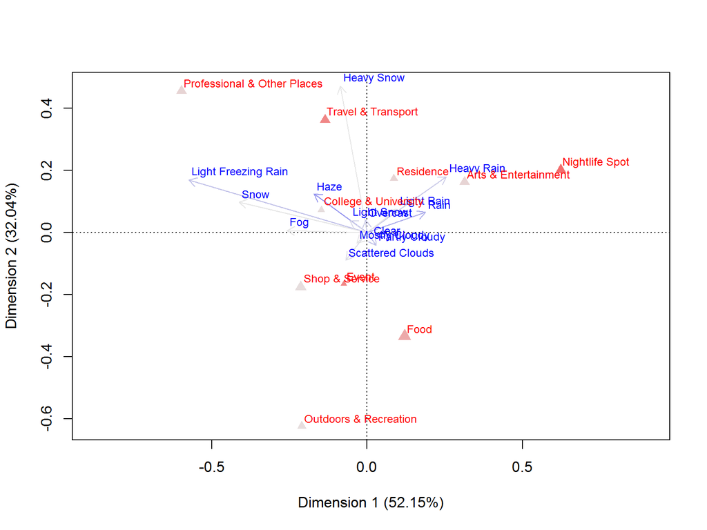

```r
#plot(fit) # symmetric map
plot(fit, mass = TRUE, contrib = "absolute", map ="rowgreen",
     arrows = c(TRUE, FALSE)) # asymmetric map
```

### 3. Model - derivation and corresponding functions

Under the assumption $H=i$ is independent from $W=j$ $P(C=k|H=i,W=j)=\frac{P(C=k,H=i,W=j)}{P(H=i,W=j)}=\frac{P(H=i,W=j|C=k)*P(C=k)}{P(H=i)*P(W=j)} (1)$

since $H=i$ is independent from $W=j$, $Exp[P(H=i,W=j|C=k)]=P(H=i|C=k)*P(W=j|C=k) (2)$

therefore, $Exp[P(C=k|H=i,W=j)]=Exp[ \frac{P(H=i,W=j|C=k)*P(C=k)} {P(H=i)*P(W=j)}] \\\ =\frac{P(H=i|C=k)*P(W=j|C=k)*P(C=k)}{P(H=i)*P(W=j)} \\\ =\frac{\frac{P(H=i,C=k)}{P(C=k)}*\frac{P(W=j,C=k)}{P(C=k)}*P(C=k)}{P(H=i)*P(W=j)} \\\ =\frac{P(C=k|H=i)*P(H=i)*P(C=k|W=j)*P(W=j)}{P(H=i)*P(W=j)*P(C=k)} \\\ =\frac{P(C=k|H=i)*P(C=k|W=j)}{P(C=k)} (3)$

- relevance contextualized by temporal factor

$P_{u}(C=k|H=i)=\frac{\Phi_{u}(C=k,H=i)}{\Phi_{u} (H=i)} (4)$

```r
get.temporal.impact <- function(dataframe,hour){
    # dataframe.in.hour = checkin.single[which(checkin.single$hour==hour),]
    dataframe.in.hour = dataframe[which(dataframe$hour==hour),]
    phi.h = nrow(dataframe.in.hour)

    list.category = split(dataframe.in.hour, dataframe.in.hour$cate_l2)
    sapply(list.category, function(i){
        nrow(i)/phi.h
    })
}
```

- relevance contextualized by (unweighted meteorological) factor

$P_{u}(C=k|W=j)=\frac{Intercept(C=k,W=j)}{\sum Intercept(C,W=j)} (5)$

```r
get.meteorological.impact <- function(fit,conds){

    conds.id = which(fit[["rownames"]]==conds)
    ref.vec = fit[["rowcoord"]][conds.id,1:8]
    cate.all = fit[["colcoord"]][,1:8]

    intercepts = apply(cate.all, 1, function(x){
        (x[1]*ref.vec[1] + x[2]*ref.vec[2] + x[3]*ref.vec[3] + x[4]*ref.vec[4] +
             x[5]*ref.vec[5] + x[6]*ref.vec[6] + x[7]*ref.vec[7] + x[8]*ref.vec[8] ) /
            (ref.vec[1]^2 + ref.vec[2]^2 + ref.vec[3]^2 + ref.vec[4]^2 +
                 ref.vec[5]^2 + ref.vec[6]^2 + ref.vec[7]^2 + ref.vec[8]^2 )
        } )

#     vec = intercepts / sum(intercepts)  !!!wrong!!! intercetp can be negative
    vec = (intercepts - min(intercepts)) / (max(intercepts)-min(intercepts)) # scale into [0,1]
    names(vec) = fit[["colnames"]]

    vec
}

get.meteorological.impact2 <- function(dataframe,conds){

    dataframe.in.conds = dataframe[which(dataframe$conds==conds),]
    phi.c = nrow(dataframe.in.conds)

    list.category = split(dataframe.in.conds, dataframe.in.conds$cate_l2)
    sapply(list.category, function(i){
        nrow(i)/phi.c
    })
}
```

- weighted meteorological factor

$P_{u}^{*} (C=k|W=j)= w_{j}*[P_{u}(C=k|W=j)-\bar P_{u}]+\bar P_{u}$

```r
get.weather.weight <- function(fit){

    conds.all = fit[["rowcoord"]][,1:2]

    mag = apply(conds.all, 1, function(x){
        sqrt( (x[1]^2+x[2]^2) )
        } )

    mag / sum(mag)
}

get.weighted.meteorological.impact <- function(fit, conds, weight){

#     cate.conds = xtabs(~conds+cate_l2, data=dataframe)
#     fit <- ca(cate.conds)

    unweighted = get.meteorological.impact(fit,conds)
#     weights = get.weather.weight(fit)

#     conds.id = which(fit[["rownames"]]==conds)

#     vec = weights[conds.id] * (unweighted-mean(unweighted)) + mean(unweighted)
    vec = weight * (unweighted-mean(unweighted)) + mean(unweighted)
    names(vec) = fit[["colnames"]]

    vec

}


get.weighted.meteorological.impact2 <- function(dataframe, conds, weight){


    unweighted = get.meteorological.impact2(dataframe, conds)

    weight * (unweighted-mean(unweighted)) + mean(unweighted)


}
```

- denominator (unweighted relevance)

$P(C=k)=\frac{\Phi_{u} (C=k) }{\Phi_{u} }$

```r
get.denominator <- function(dataframe){

    phi.h = nrow(dataframe)

    list.category = split(dataframe, dataframe$cate_l2)
    denominator = sapply(list.category, function(i){
        nrow(i)/phi.h
    })

    denominator


}
```

- the final result

$E[P(C=k|H=i,W=j)]=\frac{P(C=k|H=i)*P(C=k|W=j)}{P(C=k)}$

**update @2014.09.04**

- This equation has been somehow verified :
  - although `p.k` has a relatively high performance, multipling it with others do not bringer a higher one; instead, dividing does.
- There should be some problems in the meteorological impacts.
  - The performance based on calculation of interception is so poor that it totally brings down the whole performance. Instead, if just the simple probability distribution is adopted, the performance is getting better.

**update @2014.09.05**

- problem has been found out. In the earlier function `get.meteorological.impact()`, I used `intercept/sum(intercept)`, where `intercept` can be negative, and the `sum(intercept)` can be nonsense. Now it is fixed to `(intercepts - min(intercepts)) / (max(intercepts)-min(intercepts))` to scale into [0,1].
- besides, about the equation again:
  - if `p.j` is calculated by just using the probability distribution, then the equation `p.kij = p.ki * p.kj / p.k` is correct (which confirmes our derivation);
  - if `p.j` is calculated by personal CA, it should be noticed that the *scaled interception* does not describe *the probability of C=k under the condition W=j*. Instead, it describes the negative/positive impacts. Hence, the conditional probability should be the *scaled interception* multipled by the priori `p.k`. Therefore, here the final result should be `p.kij = p.ki * p.kj`.
  - with a little differnt equations and different methods of getting `p.j`, the above two ways have very similar results (which is expected!).

```r
get.overall.relevance <- function(dataframe,hour, conds){

    p.k = get.denominator(dataframe)
    p.ki = get.temporal.impact(dataframe, hour)
    cates.list = names(p.k)

    #cate.conds = xtabs(~conds+cate_l2, data=checkin.global)
    cate.conds = xtabs(~conds+cate_l2, data=dataframe)
    cate.conds = 100*cate.conds+1  # avoid 0s
    fit = ca(cate.conds)
    weight = get.weather.weight(fit)[which(fit[["rownames"]]==conds)]


    p.kj = get.weighted.meteorological.impact(fit,conds,weight)[cates.list]
    p.kij = p.ki * p.kj

#     p.kj = get.meteorological.impact2(dataframe, conds)
#     p.kij = p.ki * p.kj / p.k

    list("init"=p.k, "overall"=p.kij)
}
```

- generate prediction list for specified time (n-sized)

```r
generate.list = function(dataframe, hour, day){

    reference.data = dataframe[which(dataframe$hour==hour & dataframe$yearday == day),]
    conds = reference.data[1,"conds"]

    places.been.to = unique(reference.data$cate_l2)

    probs = get.overall.relevance(dataframe, hour, conds)

    probs.overall = probs[["overall"]]
    probs.overall = probs.overall[probs.overall>0]
    places.predicted.overall = names(probs.overall)[order(probs.overall,decreasing=TRUE)]

    probs.init = probs[["init"]]
    probs.init = probs.init[probs.init>0]
    places.predicted.init = names(probs.init)[order(probs.init,decreasing=TRUE)]


#     probs = probs[probs>0]
#     places.predicted = names(probs)[order(probs,decreasing=TRUE)]

    list("hour"=hour, "conds"=conds, "real"=places.been.to,
         "pred.init" =places.predicted.init,
         "pred.overall" =places.predicted.overall)

}
```

- verification function

```r
evaluation.vec = function(gen.list, n){

    real = gen.list[["real"]]
    pred.init = gen.list[["pred.init"]][1:n]
    pred.init = pred.init[!is.na(pred.init)]
    pred.overall = gen.list[["pred.overall"]][1:n]
    pred.overall = pred.overall[!is.na(pred.overall)]

    correct.init = 0; correct.overall=0
    for(i in  1:length(pred.init)){
        prediction = pred.init[i]
        if(length(which(real==prediction)))
            correct.init = correct.init+1
    }
    for(i in  1:length(pred.overall)){
        prediction = pred.overall[i]
        if(length(which(real==prediction)))
            correct.overall = correct.overall+1
    }

    real.count = length(real)
    pred.init.count = length(pred.init)
    pred.overall.count = length(pred.overall)

    c("list.size"=n,"real"=real.count,
      "pred.init"=pred.init.count,"cor.init"=correct.init,
      "pred.overall"=pred.overall.count,"cor.overall"=correct.overall)

}
```

### Experiment

- Experiment with a single user (with verification)

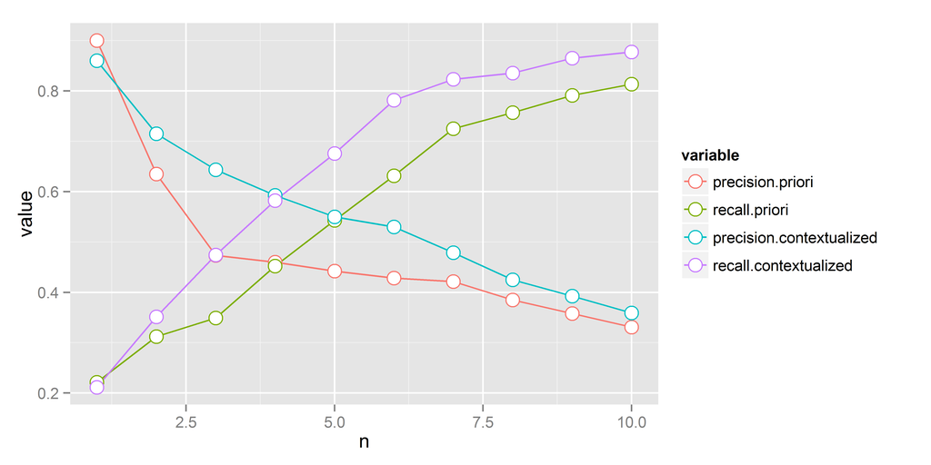

```r
# random sample
all.id = 1:nrow(checkin.single)
size.tests = 100
size.list = 10

sample.id = sample(all.id, size.tests)

performance = data.frame()

for (i in 1:size.tests){
    id = sample.id[i]
    hour = checkin.single[id,"hour"]
    day = checkin.single[id,"yearday"]

    # prediction list
    pred.list = generate.list(checkin.single, hour, day)

    for(n in 1:size.list){
        performance=rbind(performance, evaluation.vec(pred.list,n))
    }

}
colnames(performance)=c("list.size","real","pred.init","cor.init","pred.overall","cor.overall")


performance.by.size = split(performance,performance$list.size)
precision.recall = sapply(performance.by.size, function(i){
    n = i[1,"list.size"]
    precision.init = sum(i$cor.init) / sum(i$pred.init)
    recall.init = sum(i$cor.init) / sum(i$real)
    precision.overall = sum(i$cor.overall) / sum(i$pred.overall)
    recall.overall = sum(i$cor.overall) / sum(i$real)

    c("n"=i[1,"list.size"],"precision.priori"=precision.init,"recall.priori"=recall.init,
      "precision.contextualized"=precision.overall,"recall.contextualized"=recall.overall)
})

precision.recall=as.data.frame(t(precision.recall))
precision.recall= melt(precision.recall,id.vars="n")


# plot
# ppi=300
# png(paste0(basedir,"img\\plot_precision_recall_userD.png"), width = 8*ppi, height = 4*ppi, res=ppi)
# ggplot(data=precision.recall, aes(x=n, y=value, group = variable, colour = variable)) +
#     geom_line() +
#     geom_point( size=4, shape=21, fill="white")
# dev.off()

ggplot(data=precision.recall, aes(x=n, y=value, group = variable, colour = variable)) +
    geom_line() +
    geom_point( size=4, shape=21, fill="white")
```